# Bayesiansk statistik

### Låt oss demonstrera ett enkelt exempel på bayesiansk inferens

##### Låt säga att vi har ett häftstift. Vi kastar häftstiftet på bordet, och det kan då lända med spetsen uppåt, eller spetsen nedåt. Som ett experiment kastar vi häftstiftet 15 gånger, varav det landar 4 gånger med spetsen nedåt. Vad är sannolikheten för att häftstiftet landar med spetsen nedåt (*p*)?

Med klassisk statistik kan vi beräkna:

- Väntevärde - Hur många gånger häftstiftet landar med spetsen nedåt, om vi utför experimentet ett stort antal gånger.
- Varians - Hur mycket det förväntade värdet kommer slå upp eller ner mellan två oberoende försök.
- Konfidensintervall - Ett intervall för parametern *p*, för vilket gäller att för ett stort antal stickprov, så kommer vi 95% av gångerna inkludera den sanna parametern *p*

Med en Bayesiansk approach låter vi istället parametern *p* vara en slumpvariabel, och undersöker dess fördelning. Vad vi då får är alltså en fördelning som beskriver hur *sannolikt* det är att *p* antar ett specifikt värde. Låt oss testa en enkel bayesiansk metod för inferens. **Approximate Bayesian Computation**

### Importera en rad paket och fördelningar

```python
import pandas as pd
import numpy as np

from scipy.stats import binom
from scipy.stats import uniform

import seaborn as sns
import matplotlib.pyplot as plt
```

### Defininera en prior - $P(\theta)$

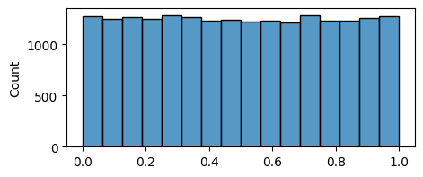

```python
draws = 20000

prior = pd.Series(uniform.rvs(0, 1, size=draws))
fig, ax = plt.subplots(figsize=(5,2));
sns.histplot(prior, bins = 16);
```

### Definiera en generative model

```python
def generative_model(p):
    result = binom.rvs(n=15, p=p)
    return result
```

```python
generative_model([0.2,0.5,0.15])
```

```
array([ 7, 10,  2], dtype=int64)
```

### Använd generative_model() för att simulera värden på x givet p.

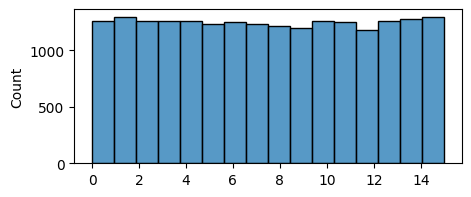

```python
pin_up = list()

for p in prior:
    pin_up.append(generative_model(p))

fig, ax = plt.subplots(figsize=(5,2));
sns.histplot(pin_up, bins=16);
```

### Generera posterior från Likelihood och Prior

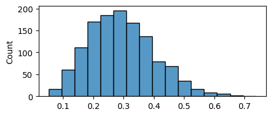

```python
observed_data = 4

posterior = prior[list(map(lambda x: x == observed_data, pin_up))]

fig, ax = plt.subplots(figsize=(5,2));
sns.histplot(posterior, bins=16);
```

### Plotta Prior och Posterior

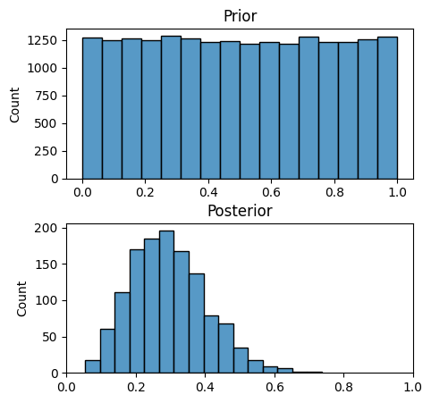

```python
fig, axs = plt.subplots(2,1, figsize=(5,5))
sns.histplot(ax=axs[0], data=prior, bins=16).set(title='Prior')
sns.histplot(ax=axs[1], data=posterior, bins=16).set(title='Posterior')
plt.subplots_adjust(hspace=0.3)
axs = axs[1].set(xlim=(0,1)) # Sätt gränsvärden för x-axel
```

### Prior : $P(\theta)$ : Prior

##### Prior är våra antaganden om $\theta$ innan vi tagit hänsyn till data.

Var kommer data ifrån?  
Vilken fördelning tror vi är sannolik?  
Har data några begränsningar?

Ofta startar man med en så kallad non-informative prior, t.ex. en likformig fördelning.

Annars kan en prior användas där t.ex. expertis och subjektivitet har tagits i beaktning. I Bayesiansk inferens är det helt OK!

### Posterior : $P(\theta|D)$

##### Posterior beskriver hur säkra vi är på att våra parametrar $\theta$ gäller, givet vår data $D$ vi observerat.

Att beräkna fördelningen posterior är målet med Bayesiansk inferens!  
Det är med hjälp av posterior som vi kan göra olika utfästelser om parametrar utifrån vår observerade data.

Exempelvis kan vi beräkna ett 95% Credible Interval för en parameter $\mu$. Det kommer då vara 95% sannolikt att det sanna $\mu$ befinner sig inom intervallet.

### Likelihood : $P(D|\theta)$

##### Likelihood är sannolikheten att vi observerar vår data $D$, om vårt antagande om $\theta$ (vår prior) visar sig stämma. Likelihood är inte en strikt sannolikhet, i den mening att den total sannolikheten inte nödvändigtvis blir 1. Den kallas ibland också *sampling distribution*

##### Att konstruera en Likelihood-funktion handlar i enkla fall oftast om att beskriva vilken fördelning utfallen förväntas komma från. Slantsingling? $\rightarrow$ Binomialfördelning Medelvärde av en eller flera oberoende slumpvariabler? $\rightarrow$ Normalfördelning Väntetid mellan slumpmässiga event? $\rightarrow$ Exponentialfördelning Antal slumpmässiga event under en viss tid? $\rightarrow$ Poissonfördelning I mer komplicerade fall räcker inte någon av de vanliga fördelningarna, utan statistikern får helt enkelt bygga en egen statistisk modell.

##### **Reflektion:** Notera att valet av likelihood återigen är subjektivt!

### Normeringskonstant : $P(D)$

##### Normeringskonstanten beror enbart av vår data, och är det som gör att vår posterior blir en total sannolikhet som integrerar till 1. Vi "behöver" inte beräkna normeringskonstanten, $Posterior$ kommer alltid vara proportionerlig mot $Likelihood * Prior$. Minns Bayes sats $P(A|B) = \dfrac{P(B|A)P(A)}{P(B)} \rightarrow P(A|B) \propto P(B|A)P(A)$ I enkla fall kan normeringskonstanten beräknas som summan av Likelihood-funktionen.

### Bayesiansk inferens i Python

Det finns flera paket för att arbeta med Bayesianska modeller i Python. Ett av de vanligare (som jag tror ni kommer arbeta med senare i utbildningen) heter [PyMC](https://www.pymc.io/welcome.html). MC står här för Markov Chain Monte Carlo vilket är en Bayesiansk metod.